# DA5020.A4.Jiaming.Xu

Assignment 4

Jiaming Xu

2/7/2022

##Q1:

According to data set dictionary, VendorID, RateCodeID, Payment_type, Trip_type are categorical variables, therefore conver them into factor.

1. Remove rows of pickup date and dropoff date both not in Feburary.
2. Drop ehail_fee column since only NA in it.

```r
library(tidyverse)
library(dplyr)
df <- read_csv("https://s3.amazonaws.com/nyc-tlc/trip+data/green_tripdata_2020-02.csv")
str(df)
```

```
## spec_tbl_df [398,632 × 20] (S3: spec_tbl_df/tbl_df/tbl/data.frame)
##  $ VendorID             : num [1:398632] 2 2 2 2 2 2 2 2 2 2 ...
##  $ lpep_pickup_datetime : POSIXct[1:398632], format: "2020-02-01 00:10:25" "2020-02-01 00:16:59" ...
##  $ lpep_dropoff_datetime: POSIXct[1:398632], format: "2020-02-01 00:14:34" "2020-02-01 00:21:35" ...
##  $ store_and_fwd_flag   : chr [1:398632] "N" "N" "N" "N" ...
##  $ RatecodeID           : num [1:398632] 1 1 1 1 1 1 1 1 1 1 ...
##  $ PULocationID         : num [1:398632] 74 74 223 145 166 166 7 112 212 212 ...
##  $ DOLocationID         : num [1:398632] 41 74 7 145 166 41 173 80 213 58 ...
##  $ passenger_count      : num [1:398632] 1 1 1 1 1 1 1 1 3 3 ...
##  $ trip_distance        : num [1:398632] 0.76 0.72 0.89 1.12 0.65 1.11 2.89 0.87 2.18 3.19 ...
##  $ fare_amount          : num [1:398632] 4.5 5 6 6 4 6 14 6 10 10.5 ...
##  $ extra                : num [1:398632] 0.5 0.5 0.5 0.5 0.5 0.5 0.5 0.5 0.5 0.5 ...
##  $ mta_tax              : num [1:398632] 0.5 0.5 0.5 0.5 0.5 0.5 0.5 0.5 0.5 0.5 ...
##  $ tip_amount           : num [1:398632] 0 0 1.82 0 1.06 0 0 0 0 0 ...
##  $ tolls_amount         : num [1:398632] 0 0 0 0 0 0 0 0 0 0 ...
##  $ ehail_fee            : logi [1:398632] NA NA NA NA NA NA ...
##  $ improvement_surcharge: num [1:398632] 0.3 0.3 0.3 0.3 0.3 0.3 0.3 0.3 0.3 0.3 ...
##  $ total_amount         : num [1:398632] 5.8 6.3 9.12 7.3 6.36 7.3 15.3 7.3 11.3 11.8 ...
##  $ payment_type         : num [1:398632] 2 1 1 2 1 2 2 2 2 2 ...
##  $ trip_type            : num [1:398632] 1 1 1 1 1 1 1 1 1 1 ...
##  $ congestion_surcharge : num [1:398632] 0 0 0 0 0 0 0 0 0 0 ...
##  - attr(*, "spec")=
##   .. cols(
##   ..   VendorID = col_double(),
##   ..   lpep_pickup_datetime = col_datetime(format = ""),
##   ..   lpep_dropoff_datetime = col_datetime(format = ""),
##   ..   store_and_fwd_flag = col_character(),
##   ..   RatecodeID = col_double(),
##   ..   PULocationID = col_double(),
##   ..   DOLocationID = col_double(),
##   ..   passenger_count = col_double(),
##   ..   trip_distance = col_double(),
##   ..   fare_amount = col_double(),
##   ..   extra = col_double(),
##   ..   mta_tax = col_double(),
##   ..   tip_amount = col_double(),
##   ..   tolls_amount = col_double(),
##   ..   ehail_fee = col_logical(),
##   ..   improvement_surcharge = col_double(),
##   ..   total_amount = col_double(),
##   ..   payment_type = col_double(),
##   ..   trip_type = col_double(),
##   ..   congestion_surcharge = col_double()
##   .. )
##  - attr(*, "problems")=<externalptr>
```

```r
df_clean <- df %>%
    mutate_at( vars( VendorID, RatecodeID, payment_type, trip_type), as.factor) %>%
    mutate( pick_up_month = format( lpep_pickup_datetime, "%Y-%b")) %>%
    mutate( drop_off_month = format( lpep_dropoff_datetime, "%Y-%b")) %>%
    filter(  !( drop_off_month != "2020-Feb" & pick_up_month != "2020-Feb")) %>%
    dplyr::select( -ehail_fee)

df_clean
```

```
## # A tibble: 398,614 × 21
##    VendorID lpep_pickup_datetime lpep_dropoff_datet… store_and_fwd_f… RatecodeID
##    <fct>    <dttm>               <dttm>              <chr>            <fct>
##  1 2        2020-02-01 00:10:25  2020-02-01 00:14:34 N                1
##  2 2        2020-02-01 00:16:59  2020-02-01 00:21:35 N                1
##  3 2        2020-02-01 00:19:31  2020-02-01 00:25:29 N                1
##  4 2        2020-02-01 00:43:52  2020-02-01 00:48:58 N                1
##  5 2        2020-02-01 00:32:53  2020-02-01 00:35:19 N                1
##  6 2        2020-02-01 00:04:36  2020-02-01 00:10:09 N                1
##  7 2        2020-02-01 00:49:36  2020-02-01 01:07:27 N                1
##  8 2        2020-02-01 00:21:08  2020-02-01 00:28:16 N                1
##  9 2        2020-02-01 00:05:16  2020-02-01 00:16:25 N                1
## 10 2        2020-02-01 00:59:48  2020-02-01 01:06:26 N                1
## # … with 398,604 more rows, and 16 more variables: PULocationID <dbl>,
## #   DOLocationID <dbl>, passenger_count <dbl>, trip_distance <dbl>,
## #   fare_amount <dbl>, extra <dbl>, mta_tax <dbl>, tip_amount <dbl>,
## #   tolls_amount <dbl>, improvement_surcharge <dbl>, total_amount <dbl>,
## #   payment_type <fct>, trip_type <fct>, congestion_surcharge <dbl>,
## #   pick_up_month <chr>, drop_off_month <chr>
```

## Q2:

I made a function to find the most common value in a vector. Use match function to find the amount of unique values, then use which.max return it’s maximum index, then extract it’s value.

The most common hail type is street-hail, and most common payment method is credit card.

```r
findMode <- function(x) {
    u <- unique(x)
    return (u[which.max(tabulate(match(x, u)))])
}
findMode(df_clean$trip_type)
```

```
## [1] 1
## Levels: 1 2
```

```r
findMode(df_clean$payment_type)
```

```
## [1] 1
## Levels: 1 2 3 4 5
```

## Q3:

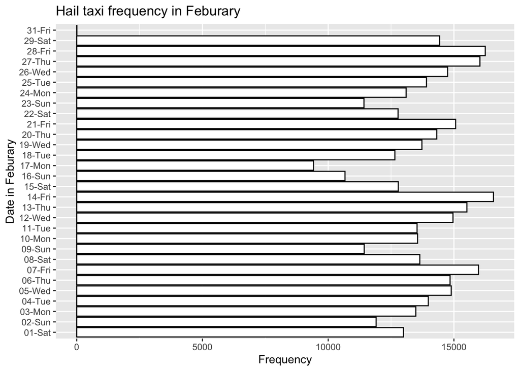

```r
df_clean %>%
    mutate( date = format(lpep_pickup_datetime, "%d-%a")) %>%
    group_by( date) %>%
    count %>%
    ggplot( )+
        geom_bar( mapping = aes( x = date, y = n),
                   fill='white', color = 'black', stat = 'identity') +
        labs( x = "Date in Feburary", y = 'Frequency', title = 'Hail taxi frequency in Feburary') +
    coord_flip()
```

## Q4:

Create a function that use str_match function in string package, use regex pattern ” (\d{2}):” and extract the second group inside the parentheses. Since str_match returns a matrix, remember use [, 2] to take out second column from result.

```r
library(stringr)
HourOfDay <- function(x){
    return (str_match(x, " (\\d{2}):")[, 2])
}

HourOfDay("2020-02-01 11:10:25")
```

```
## [1] "11"
```

## Q5 - Q6:

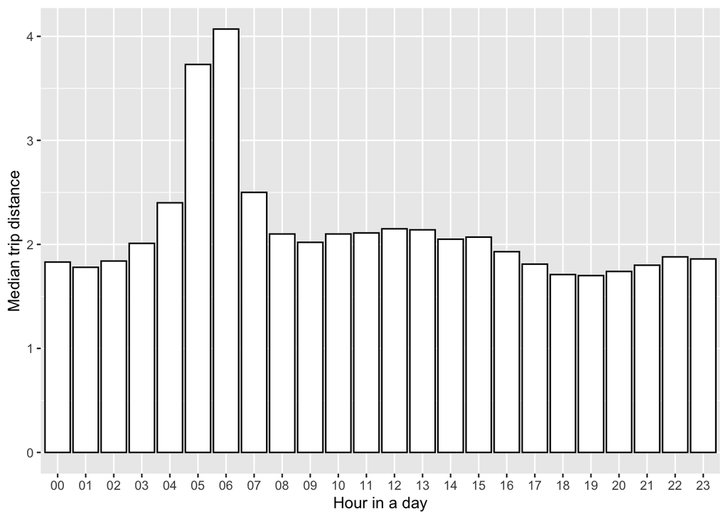

```r
df_clean %>%
    mutate( lpep_pickup_hour = HourOfDay(lpep_pickup_datetime)) %>%
    group_by( lpep_pickup_hour) %>%
    summarise( median_trip_distance = median(trip_distance)) %>%
    ggplot() +
        geom_bar( mapping = aes( x = lpep_pickup_hour, y = median_trip_distance)
                  , fill ='white', color = 'black', stat = 'identity') +
        labs( x = "Hour in a day", y = "Median trip distance")
```

## Q7:

I tried to use “count” function in pipe but failed to use filter function to find the maximum value, therefore I used summarise function to count in each group.

People hailed taxi on valentine’s day the most on February!

```r
df_clean %>%
    mutate(day = format( lpep_pickup_datetime, '%b-%d')) %>%
    group_by(day) %>%
    summarise(n = n()) %>%
    filter( n == max(n))
```

```
## # A tibble: 1 × 2
##   day        n
##   <chr>  <int>
## 1 Feb-14 16574
```